# Project Assingment - Pratical ML course

Lauri Niskanen

23.08.2014

# Introduction

This study is part of the *[Practical Machine Learning](https://www.coursera.org/course/predmachlearn)* course by *Johns Hopkins University*. Dataset for this analysis is kindly provided by http://groupware.les.inf.puc-rio.br/har.

The goal of this study project is to predict the manner how these exercies were carried out.

# Download, settings, type conversions

- After inspection of the data, only numeric variables with standard deviation greater than zero are kept
- Also some obvious variables are removed such as user_names, datetime variables and so on

```r
library(caret)
```

```r
library(ggplot2)
set.seed(234567)

# set download paths and file names
trainFileUrl<-"https://d396qusza40orc.cloudfront.net/predmachlearn/pml-training.csv"
testFileUrl<-"https://d396qusza40orc.cloudfront.net/predmachlearn/pml-testing.csv"
dataDir<-"./data"
trainFile<-paste0(dataDir,"/pml-training.csv")
testFile<-paste0(dataDir,"/pml-testing.csv")

# create data storage directory if not existing
if (! file.exists(dataDir) ) {dir.create(dataDir)}

# download files if not already downloaded
if( ! file.exists(trainFile)) download.file(trainFileUrl, trainFile, "curl", quiet = FALSE, mode = "w", cacheOK = TRUE)
if( ! file.exists(testFile)) download.file(testFileUrl, testFile, "curl", quiet = FALSE, mode = "w",cacheOK = TRUE)


# read traing/test data and un-categorized data files
Data<-read.csv(trainFile,header = TRUE,sep=",",na.strings = c("NA","#DIV/0!"),
               stringsAsFactors = FALSE)


# Unrelated columns
names(Data)[c(1,2,3,4,5,6,7)]
```

```
## [1] "X"                    "user_name"            "raw_timestamp_part_1"
## [4] "raw_timestamp_part_2" "cvtd_timestamp"       "new_window"
## [7] "num_window"
```

```r
# Drop unrelated fields for categorization modeling:
Data<-Data[,-c(1,2,3,4,5,6,7)]


# Split data to training and test sets
inTrain<-createDataPartition(Data$classe,p=0.8,list=FALSE)
train<-Data[inTrain,]
test<-Data[-inTrain,]

# temporarily store classe due to further cleaning
trainOutput<-train$classe
testOutput<-test$classe

# Keeping only numeric variables that have variability
keep<-which(sapply(train,sd)>0)
save(keep,file="./keepvariables")
train<-train[,keep]
test<-test[,keep]



# place output variables back into data frame
train$classe<-as.factor(trainOutput)
test$classe<-as.factor(testOutput)

# summaries kept variables
names(train)
```

```
##  [1] "roll_belt"            "pitch_belt"           "yaw_belt"
##  [4] "total_accel_belt"     "gyros_belt_x"         "gyros_belt_y"
##  [7] "gyros_belt_z"         "accel_belt_x"         "accel_belt_y"
## [10] "accel_belt_z"         "magnet_belt_x"        "magnet_belt_y"
## [13] "magnet_belt_z"        "roll_arm"             "pitch_arm"
## [16] "yaw_arm"              "total_accel_arm"      "gyros_arm_x"
## [19] "gyros_arm_y"          "gyros_arm_z"          "accel_arm_x"
## [22] "accel_arm_y"          "accel_arm_z"          "magnet_arm_x"
## [25] "magnet_arm_y"         "magnet_arm_z"         "roll_dumbbell"
## [28] "pitch_dumbbell"       "yaw_dumbbell"         "total_accel_dumbbell"
## [31] "gyros_dumbbell_x"     "gyros_dumbbell_y"     "gyros_dumbbell_z"
## [34] "accel_dumbbell_x"     "accel_dumbbell_y"     "accel_dumbbell_z"
## [37] "magnet_dumbbell_x"    "magnet_dumbbell_y"    "magnet_dumbbell_z"
## [40] "roll_forearm"         "pitch_forearm"        "yaw_forearm"
## [43] "total_accel_forearm"  "gyros_forearm_x"      "gyros_forearm_y"
## [46] "gyros_forearm_z"      "accel_forearm_x"      "accel_forearm_y"
## [49] "accel_forearm_z"      "magnet_forearm_x"     "magnet_forearm_y"
## [52] "magnet_forearm_z"     "classe"
```

```r
# trainig and test set dimensions respectivly
dim(train); dim(test)
```

```
## [1] 15699    53
```

```
## [1] 3923   53
```

# View to test and training data sets

Let’s check the balance of data relative to outcomes

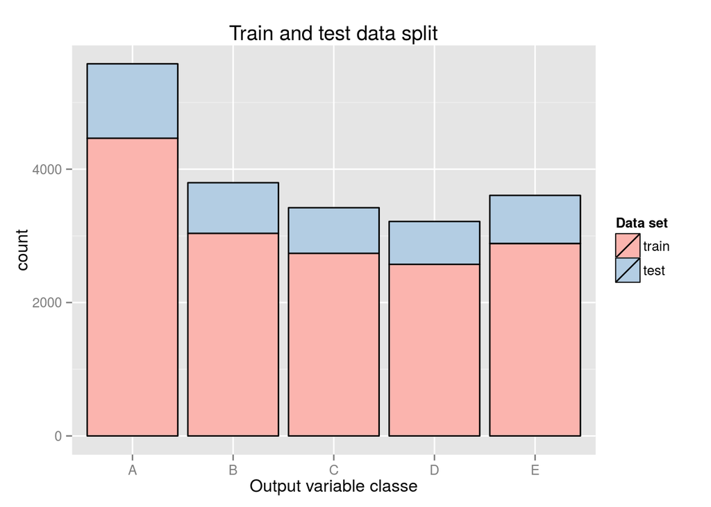

```r
# re-combine to single data set with factor variable for plotting reasons
trData<-train
trData$type<-as.factor(c("train"))
tsData<-test
tsData$type<-as.factor(c("test"))
tData<-rbind(trData,tsData)

ggplot(tData, aes( x = classe, fill = type)) +
        geom_bar( stat ="bin", colour ="black") +
        scale_fill_brewer( palette ="Pastel1")+
        xlab("Output variable classe")+
        ggtitle("Train and test data split")+
        guides( fill = guide_legend( title = "Data set"))
```

- createPartition balanced well relative cross validation data sets
- class A type is however dominant among classes

# Decision trees

Fitting with basic decision tree and investigating variable importancies

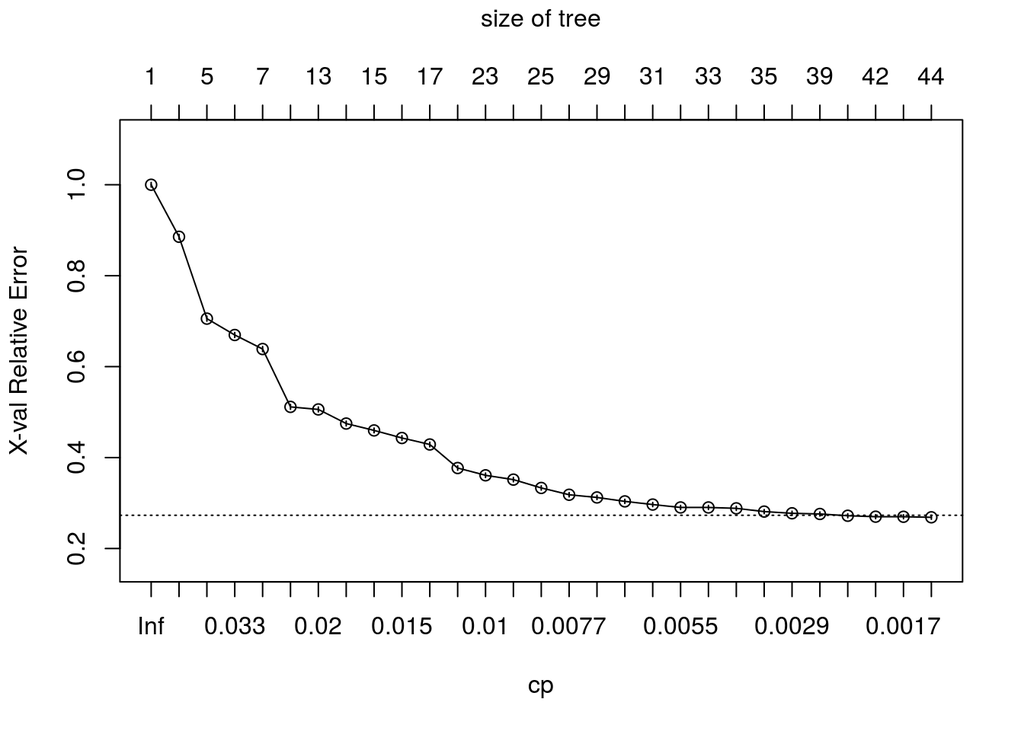

```r
library(rpart)


# require min number of obs to be 300 and the decrease of lack of fit to be 0.001
fitTree <- rpart(classe ~.,
          method="class", data=train,control=rpart.control(minsplit=300, cp=0.001))

# prune the tree
pfitTree<- prune(fitTree, cp=fitTree$cptable[which.min(fitTree$cptable[,"xerror"]),"CP"])

# plot cross-validation
plotcp(pfitTree)
```

```r
# importance order of variables in tree based classification
varImp<-names(pfitTree$variable.importance)
varImp
```

```
##  [1] "roll_belt"            "accel_belt_z"         "pitch_belt"
##  [4] "pitch_forearm"        "magnet_dumbbell_y"    "accel_dumbbell_y"
##  [7] "roll_forearm"         "yaw_belt"             "accel_forearm_x"
## [10] "total_accel_dumbbell" "magnet_dumbbell_z"    "total_accel_belt"
## [13] "magnet_belt_z"        "magnet_belt_x"        "accel_belt_y"
## [16] "roll_dumbbell"        "magnet_belt_y"        "accel_dumbbell_z"
## [19] "accel_dumbbell_x"     "yaw_forearm"          "magnet_forearm_y"
## [22] "magnet_forearm_z"     "accel_forearm_z"      "yaw_arm"
## [25] "accel_belt_x"         "magnet_forearm_x"     "gyros_belt_z"
## [28] "yaw_dumbbell"         "magnet_arm_y"         "pitch_arm"
## [31] "accel_forearm_y"      "magnet_arm_x"         "accel_arm_x"
## [34] "gyros_dumbbell_y"     "gyros_arm_x"          "magnet_arm_z"
## [37] "gyros_arm_y"          "gyros_belt_y"         "pitch_dumbbell"
## [40] "magnet_dumbbell_x"    "gyros_dumbbell_x"     "accel_arm_y"
## [43] "gyros_forearm_y"      "roll_arm"             "accel_arm_z"
## [46] "gyros_forearm_z"      "gyros_belt_x"         "gyros_forearm_x"
## [49] "total_accel_arm"
```

```r
# predicting with test data set and converting probabilities back into classes
predProbs<-predict(pfitTree,newdata=test)
pred<-apply(predProbs,1,function(X){colnames(predProbs)[which(X==max(X))]})

# Confusion matrix
cMatrix<-confusionMatrix(pred,test$classe)
round(apply(cMatrix$table,2,function(X){X/sum(X)}),3)*100
```

```
##    Reference
##        A    B    C    D    E
##   A 90.9 10.0  1.8  3.9  1.2
##   B  2.3 71.8  7.6  5.6  5.0
##   C  2.2  8.4 84.8  4.5  6.8
##   D  3.7  5.8  4.5 81.2 10.7
##   E  1.0  4.0  1.3  4.8 76.3
```

```r
# save the tree model to a file
save(pfitTree,file="fitRpartTree.RData")
```

- Prediction error rate results are not particular good
- Keeping 27 first variables as rest of variables do not seem to reduce the relative error of classification

# Random Forests

Subsetting based on previous result down to 27 variables

```r
rfModelFile<-"./fitRF.RData"

# subset train/test data
train27<-train[,varImp[c(1:27)]]
test27<-test[,varImp[c(1:27)]]

# save the final variable set to a file
finalVariableSet<-names(train27)
save(finalVariableSet,file="./finalVariables")

# add classe back to reduced set
train27$classe<-train$classe
test27$classe<-test$classe


# setting some control parameters
ctr<-trainControl(method = "oob", number = 2, repeats=2, allowParallel = TRUE)

# preprocesing data with normalization
if (!file.exists(rfModelFile)){
        fitRF<-train(classe ~., method="rf",trainControl=ctr,preProc=c("center","scale"),data=train27)}else{load(rfModelFile)}



predRF<-predict(fitRF,test27)
cMatrixRF<-confusionMatrix(predRF,test27$classe)
cMatrixRF$table
```

```
##           Reference
## Prediction    A    B    C    D    E
##          A 1116    2    0    1    0
##          B    0  756    0    0    0
##          C    0    1  681    7    0
##          D    0    0    3  634    3
##          E    0    0    0    1  718
```

```r
round(apply(cMatrixRF$table,2,function(X){X/sum(X)}),3)*100
```

```
##    Reference
##       A    B    C    D    E
##   A 100  0.3  0.0  0.2  0.0
##   B   0 99.6  0.0  0.0  0.0
##   C   0  0.1 99.6  1.1  0.0
##   D   0  0.0  0.4 98.6  0.4
##   E   0  0.0  0.0  0.2 99.6
```

```r
# save the model
save(fitRF,file=rfModelFile)
```

Conlusions:

- Out of sample error rates are on good level
- Further studies could be carried out to see how many variables are really needed to keep cross validation accuracy over 99% for each class